# The Cauchy distribution

Peter Ralph

Advanced Biological Statistics

# Stochastic minute

If $X \sim \Cauchy(\text{center}=\mu, \text{scale}=\sigma)$, then $X$ has probability density
$$\begin{aligned}
f(x \given \mu, \sigma) = \frac{1}{\pi\left( 1 + \left( \frac{x - \mu}{\sigma} \right)^2 \right)} .
\end{aligned}$$

1. The Cauchy is a good example of a distribution with “heavy tails”: rare, very large values.
2. $X$ has a Student’s $t$ distribution with $\text{df}=1$.
3. If $Z \sim \Normal(0, 1)$ and $X \sim \Normal(0,1/Z)$ then $X \sim \Cauchy(0,1)$.
4. If $X_1, X_2, \ldots, X_n$ are independent $\Cauchy(0,1)$ then $\max(X_1, \ldots, X_n)$ is of size $n$.
5. If $X_1, X_2, \ldots, X_n$ are independent $\Cauchy(0,1)$ then
   $$\begin{aligned}
   \frac{1}{n} \left(X_1 + \cdots + X_n\right) \sim \Cauchy(0,1) .
   \end{aligned}$$

*Wait, what?!?*

A single value has the *same distribution* as the mean of 1,000 of them?

Let’s look:

```r
meanplot <- function (rf, n=1e3, m=100) {
    x <- matrix(rf(n*m), ncol=m)
    layout(t(1:2))
    hist(x[1,][abs(x[1,])<5], breaks=20, freq=FALSE,
         main=sprintf("%d samples", m), xlab='value',
         xlim=c(-5,5))
    hist(colMeans(x)[abs(colMeans(x))<5], breaks=20, freq=FALSE,
         main=sprintf("%d means of %d each", m, n), xlab='value',
         xlim=c(-5,5))
}
```

$X \sim \Normal(0,1)$

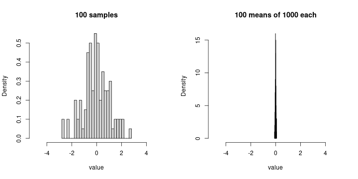

```r
meanplot(rnorm)
```

$X \sim \Cauchy(0,1)$

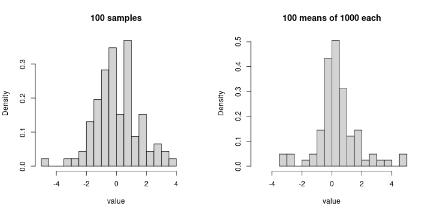

```r
meanplot(rcauchy)
```

## Another way to look at it: extreme values

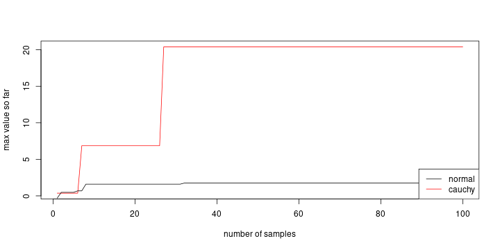

```r
n <- 100
plot(c(cummax(rcauchy(n))), type='l', ylab='max value so far', xlab='number of samples', col='red')
lines(c(cummax(rnorm(n))), col='black')
legend("bottomright", lty=1, col=c('black', 'red'), legend=c('normal', 'cauchy'))
```

## Another way to look at it: extreme values

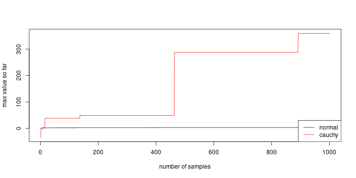

```r
n <- 1000
plot(c(cummax(rcauchy(n))), type='l', ylab='max value so far', xlab='number of samples', col='red')
lines(c(cummax(rnorm(n))), col='black')
legend("bottomright", lty=1, col=c('black', 'red'), legend=c('normal', 'cauchy'))
```

## Another way to look at it: extreme values

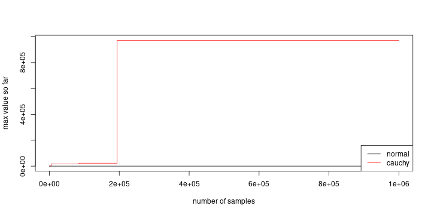

```r
n <- 1e6
plot(c(cummax(rcauchy(n))), type='l', ylab='max value so far', xlab='number of samples', col='red')
lines(c(cummax(rnorm(n))), col='black')
legend("bottomright", lty=1, col=c('black', 'red'), legend=c('normal', 'cauchy'))
```

## Exercise: mixture of error rates.

Suppose you are measuring relative metabolic rates of mice in the wild. Because life is complicated, the *accuracy* of your measurements varies widely. A model of the measured rate, $R_i$, for a mouse at temperature $T_i$ is
$$\begin{aligned}
R_i &\sim \Normal(120 + 0.7 * (T_i - 37), 1/|E_i|) \\
E_i &\sim \Normal(0, 1) .
\end{aligned}$$

Simulate 200 measurements from this model, for temperatures between 36 and 38, and try to infer the true slope (`0.7`).